# **Panorama da inflação**

Os principais índices de inflação do Brasil, apontam em agosto de 2018 um avanço da inflação de em média **0.20%**. Com esse resultado, no ano a inflação acumula uma variação média positiva de **3.85%**, e em 12 meses uma variação média acumulada de **5.57%**.

|  | Variação mensal | Variação acumulada no ano | Variação acumulada em 12 meses |
| --- | --- | --- | --- |
| IPCA | -0.09% | 2.85% | 4.19% |
| INPC | 0% | 2.83% | 3.64% |
| IGP-M | 0.7% | 5.86% | 8.89% |
| IGP-DI | 0.68% | 6.02% | 9.06% |
| IPA | 0.99% | 0.09% | 0.12% |
| IPC | 0.07% | 2.54% | 4.15% |
| INCC | 0.15% | 2.65% | 3.74% |

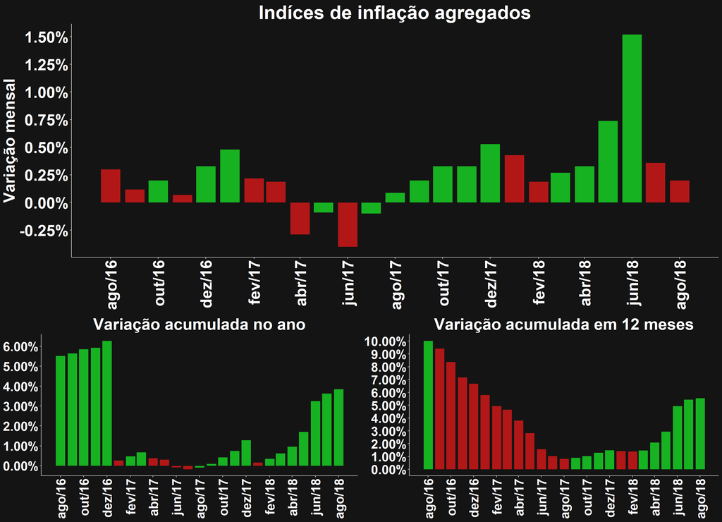

Índices selecionados para a média: IPCA, INPC e IGP-M.

# IPCA

O Indíce de Preços ao Consumidor Amplo (IPCA) variou -0.09% em agosto, valor inferior ao mesmo período do ano anterior quando apresentou uma taxa de 0.19%. Com esse resultado o indíce acumula no ano uma variação positiva de 2.85%, e em 12 meses uma variação positiva de 4.19%.

|  | 08/2017 | 07/2018 | 08/2018 |
| --- | --- | --- | --- |
| Variação mensal | 0.19% | 0.33% | -0.09% |
| Variação acumulada no ano | 1.62% | 2.94% | 2.85% |
| Variação acumulada em 12 meses | 2.46% | 4.48% | 4.19% |

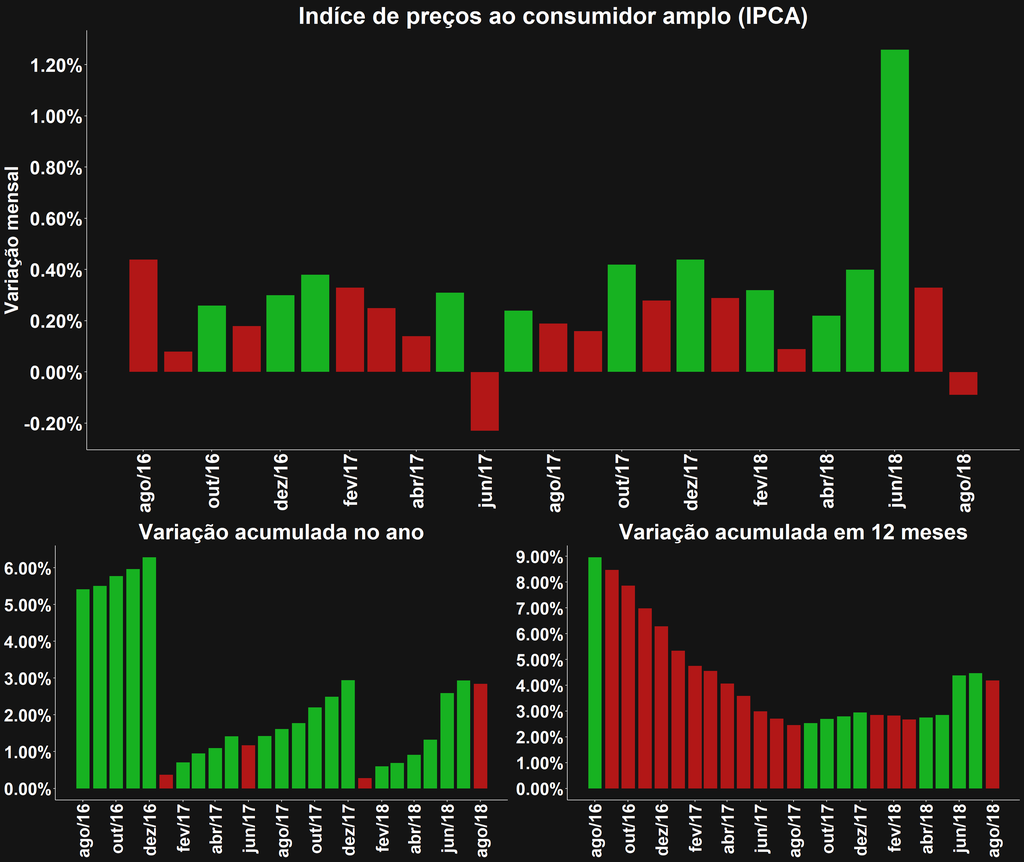

Os grupos que tiveram maior resultado positivo foram Artigos de residência (0.56%) e Saúde e cuidados pessoais (0.53%), e negativo Transportes (-1.22%) e Alimentação e bebidas (-0.34%).

|  | Variação mensal | Variação acumulada no ano | Peso mensal |
| --- | --- | --- | --- |
| Alimentação e bebidas | -0.34% | 2.47% | 24.53% |
| Habitação | 0.44% | 5.09% | 15.94% |
| Artigos de residência | 0.56% | 1.79% | 3.91% |
| Vestuário | 0.19% | -0.41% | 5.77% |
| Transportes | -1.22% | 2.85% | 18.5% |
| Saúde e cuidados pessoais | 0.53% | 3.79% | 12.08% |
| Despesas pessoais | 0.36% | 1.68% | 10.8% |
| Educação | 0.25% | 4.75% | 4.93% |
| Comunicação | 0.03% | 0.03% | 3.54% |

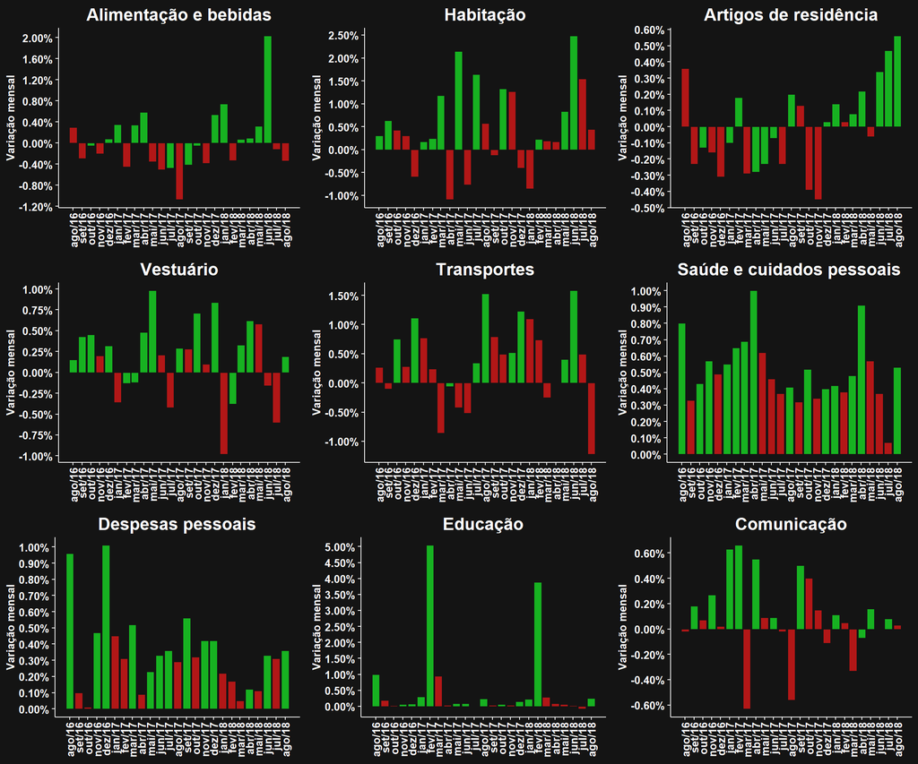

A nível de sub-itens os que mais influenciaram positivamente no resultado em relação ao seu peso foram Energia elétrica residencial (0.96%%) e Plano de saúde (0.81%%), e negativamente Passagem aérea (-26.12%%) e Gasolina (-1.45%%).

|  | Variação mensal | Variação acumulada no ano | Peso mensal |
| --- | --- | --- | --- |
| Cigarro | 1.81% | 1.84% | 1.05% |
| Energia elétrica residencial | 0.96% | 14.88% | 4.03% |
| Plano de saúde | 0.81% | 7.72% | 4.03% |
| Empregado doméstico | 0.49% | 2.39% | 4.28% |

|  | Variação mensal | Variação acumulada no ano | Peso mensal |
| --- | --- | --- | --- |
| Gasolina | -1.45% | 9.43% | 4.59% |
| Passagem aérea | -26.12% | -29.93% | 0.43% |
| Leite longa vida | -3.48% | 38.52% | 1.19% |
| Etanol | -4.69% | -6.23% | 0.94% |

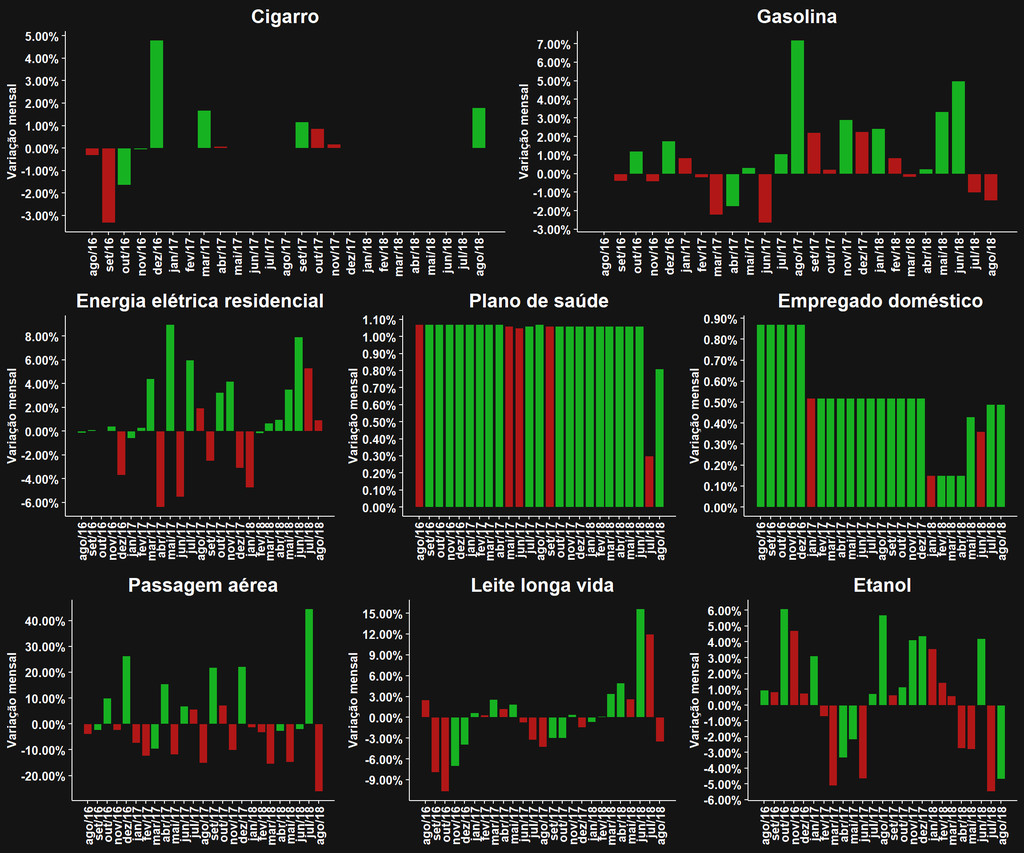

# INPC

O Indíce Nacional de Preços ao Consumidor (INPC) variou 0% em agosto, valor superior ao mesmo período do ano anterior quando apresentou uma taxa de -0.03%. Com esse resultado o indíce acumula no ano uma variação positiva de 2.83%, e em 12 meses uma variação positiva de 3.64%.

|  | 08/2017 | 07/2018 | 08/2018 |
| --- | --- | --- | --- |
| Variação mensal | -0.03% | 0.25% | 0% |
| Variação acumulada no ano | 1.27% | 2.83% | 2.83% |
| Variação acumulada em 12 meses | 1.73% | 3.61% | 3.64% |

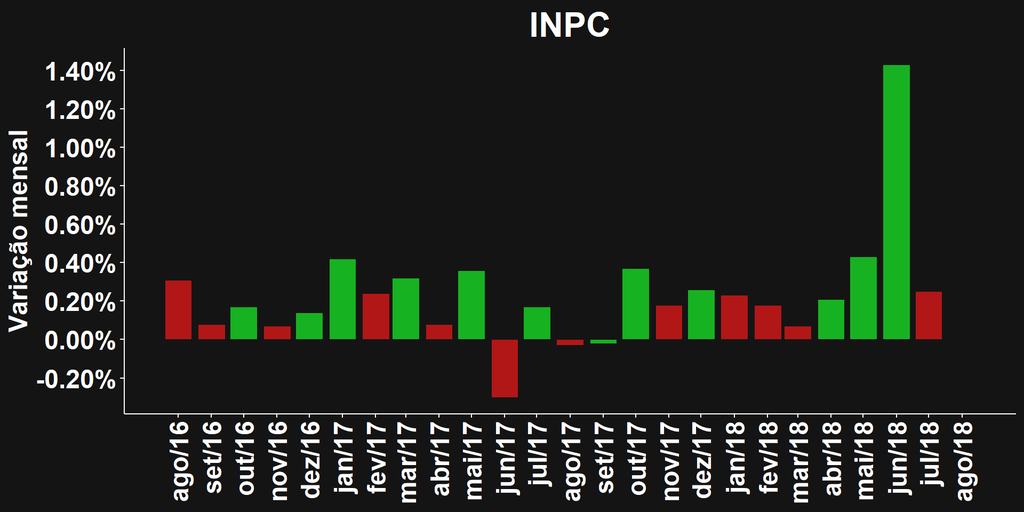

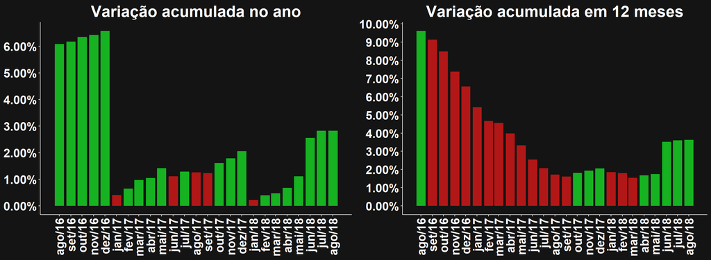

# IGP-M

O Indíce Geral de Preços de Mercado (IGP-M) variou 0.7% em agosto, valor superior ao mesmo período do ano anterior quando apresentou uma taxa de 0.1%. Com esse resultado o indíce acumula no ano uma variação positiva de 5.86%, e em 12 meses uma variação positiva de 8.89%.

|  | 08/2017 | 07/2018 | 08/2018 |
| --- | --- | --- | --- |
| Variação mensal | 0.1% | 0.51% | 0.7% |
| Variação acumulada no ano | -3.18% | 5.13% | 5.86% |
| Variação acumulada em 12 meses | -1.71% | 8.24% | 8.89% |

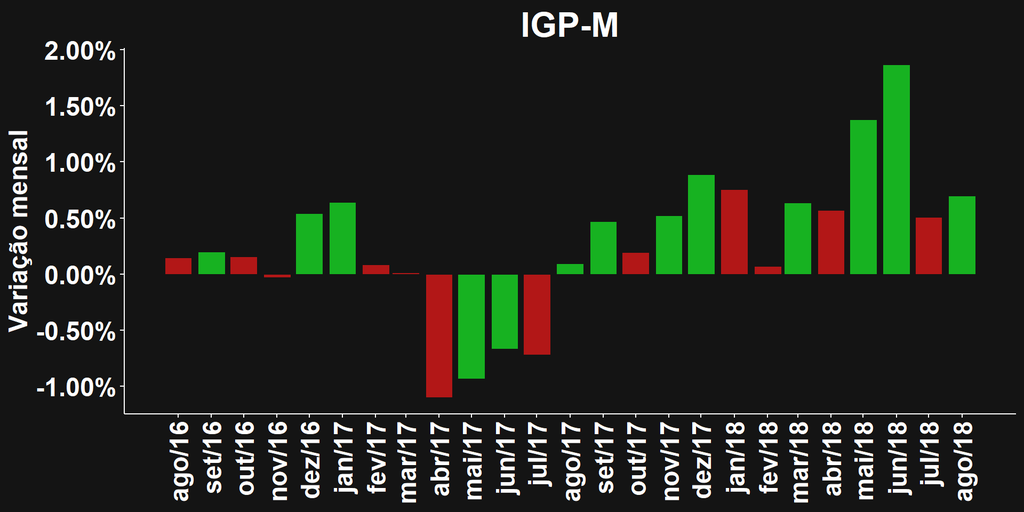

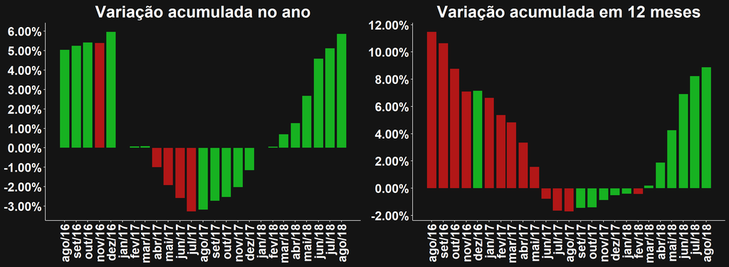

# IGP-DI

O Indíce Geral de Preços - Disponibilidade Interna (IGP-DI) variou 0.68% em agosto, valor superior ao mesmo período do ano anterior quando apresentou uma taxa de 0.24%. Com esse resultado o indíce acumula no ano uma variação positiva de 6.02%, e em 12 meses uma variação positiva de 9.06%.

|  | 08/2017 | 07/2018 | 08/2018 |
| --- | --- | --- | --- |
| Variação mensal | 0.24% | 0.44% | 0.68% |
| Variação acumulada no ano | -3.05% | 5.31% | 6.02% |
| Variação acumulada em 12 meses | -1.61% | 8.59% | 9.06% |

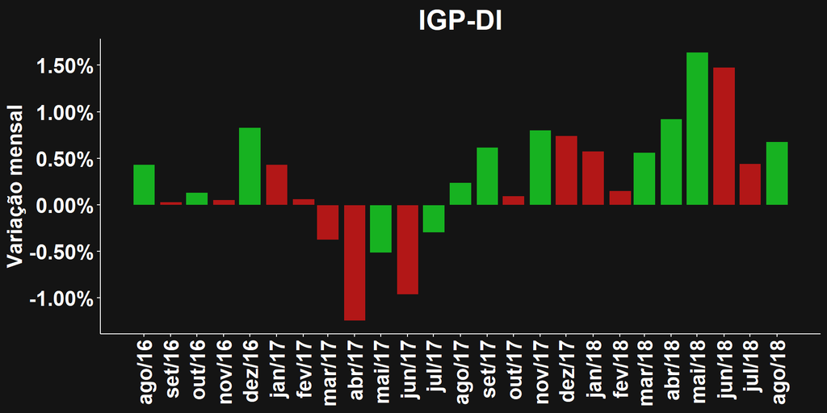

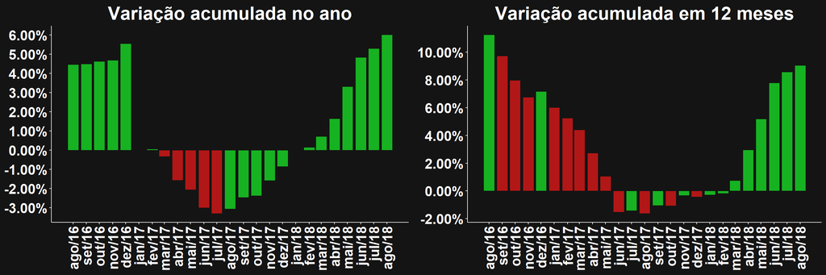

|  | 08/2017 | 07/2018 | 08/2018 |
| --- | --- | --- | --- |
| Variação mensal | 0.26% | 0.52% | 0.99% |
| Variação acumulada no ano | -0.05% | 0.08% | 0.09% |
| Variação acumulada em 12 meses | -0.04% | 0.11% | 0.12% |

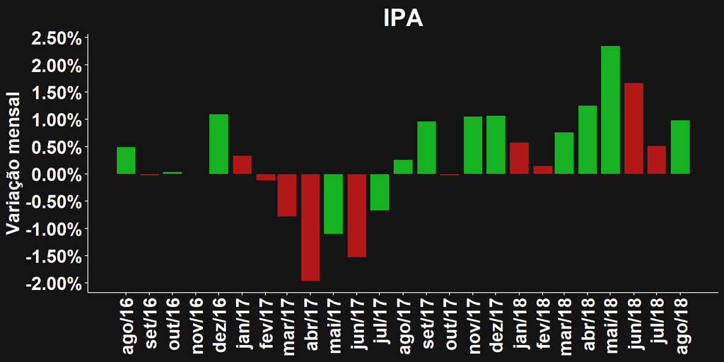

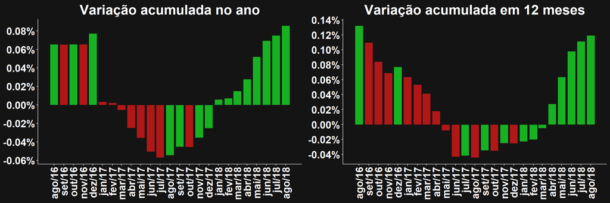

|  | 08/2017 | 07/2018 | 08/2018 |
| --- | --- | --- | --- |
| Variação mensal | 0.13% | 0.17% | 0.07% |
| Variação acumulada no ano | 1.62% | 2.47% | 2.54% |
| Variação acumulada em 12 meses | 3.26% | 4.22% | 4.15% |

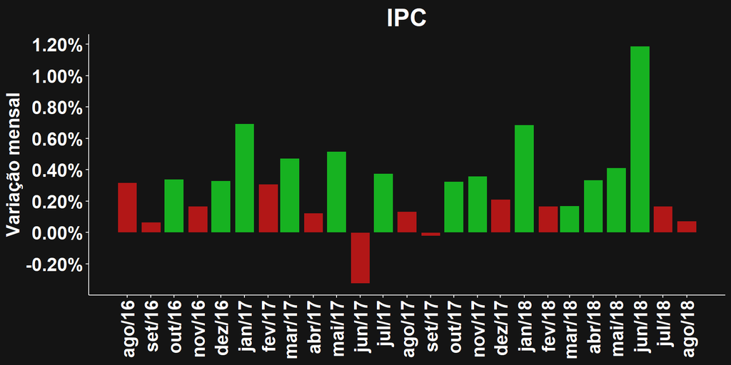

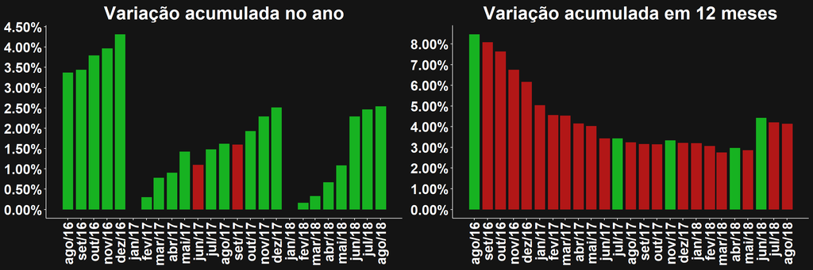

|  | 08/2017 | 07/2018 | 08/2018 |
| --- | --- | --- | --- |
| Variação mensal | 0.36% | 0.61% | 0.15% |
| Variação acumulada no ano | 3.05% | 2.5% | 2.65% |
| Variação acumulada em 12 meses | 4.57% | 3.96% | 3.74% |

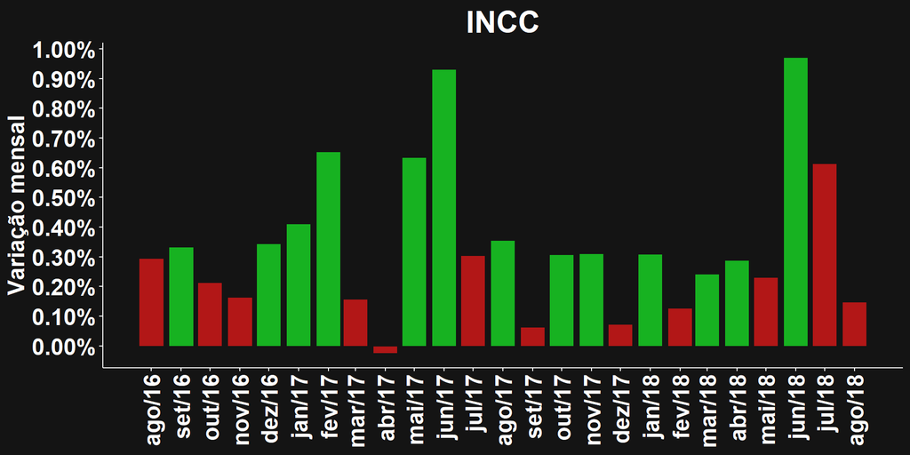

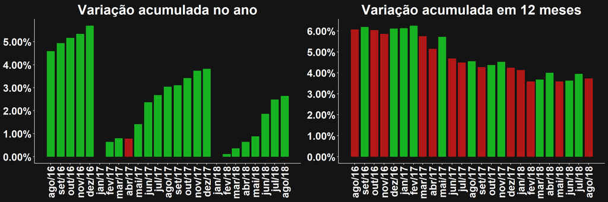

# Estatísticas

As estatísticas descritivas a seguir são feitas com base nos últimos 48 meses, e tem como objetivo possibilitar a avaliação do resultado observado em comparação aos períodos anteriores.

|  | Minimo | 1 Quartil | Mediana | Media | 3 Quartil | Maximo | Desvio Padrão |
| --- | --- | --- | --- | --- | --- | --- | --- |
| IPCA | -0.23% | 0.26% | 0.42% | 0.51% | 0.75% | 1.32% | 0.37% |
| INPC | -0.3% | 0.18% | 0.4% | 0.5% | 0.72% | 1.51% | 0.44% |
| IGP-M | -1.1% | 0.19% | 0.52% | 0.52% | 0.84% | 1.89% | 0.64% |
| IGP-DI | -1.24% | 0.15% | 0.55% | 0.53% | 0.85% | 1.76% | 0.64% |
| IPA | -1.96% | 0.12% | 0.47% | 0.55% | 1.1% | 2.38% | 0.92% |
| IPC | -0.32% | 0.25% | 0.42% | 0.52% | 0.7% | 1.78% | 0.41% |
| INCC | -0.02% | 0.2% | 0.34% | 0.44% | 0.56% | 1.93% | 0.39% |

Levando em consideração o desvio padrão de cada indíce, proporcionalmente os que mais se afastaram da média foram o IPCA, o INPC e o IPC.

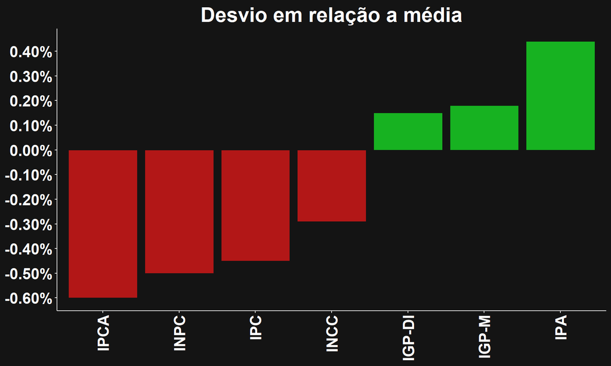

**João Victor Gomes**  
**jvg.santana@gmail.com**  
**[linkedin.com/in/jvictorgomes](https://www.linkedin.com/in/jvictorgomes/)**